# The Khan dataset

Zhoumengdi Wang (zxw534)

```r
library(ISLR)
library(tree)
library(randomForest)
library(caret)
attach(Khan)
```

## Random Forest

After looking the dataset, there are 63 subjects in training set and there are 20 subjects in test set. Every subject has 2308 features. There are 4 types of small round blue cell tumors.

First, we will set a loop of random forests with the hyperparameter `mtry` (features)from 1 to 100. The output below indicates the classification error percentage for each `mtry` value from 1-100.

```r
set.seed(0)

class.err = rep(0, 100)

for(features in 1:100)
{
  rf.khan = randomForest(x=xtrain, y=as.factor(ytrain), mtry=features)
  class.err[features] = sum(as.numeric(rf.khan$predicted != ytrain))/63
}
```

```r
cbind(features=1:100, class.err)
```

```
##        features  class.err
##   [1,]        1 0.09523810
##   [2,]        2 0.03174603
##   [3,]        3 0.03174603
##   [4,]        4 0.01587302
##   [5,]        5 0.04761905
##   [6,]        6 0.06349206
##   [7,]        7 0.01587302
##   [8,]        8 0.00000000
##   [9,]        9 0.03174603
##  [10,]       10 0.03174603
##  [11,]       11 0.01587302
##  [12,]       12 0.01587302
##  [13,]       13 0.01587302
##  [14,]       14 0.00000000
```

[output cut: 86 more lines]

Based on the results, we can see that the training set classifies perfectly when mtry is 8, 14, and most mtry values from 24 and onward.

Because there are so many candidates, I decide to do cross-validation for each mtry of these 100 random forests.

Name features:

```r
xtrain.mtx = as.matrix(xtrain)
colnames(xtrain.mtx) = make.names(1:2308, unique=T)
```

Classify 4 types of small round blue cell tumors:

```r
ytrain.releveled = as.factor(ytrain)
levels(ytrain.releveled) <- c("Type1", "Type2", "Type3", "Type4")
```

Do cross-validation:

```r
cv = trainControl(method="repeatedcv", number=5, repeats=4, classProbs=TRUE)
```

Random Forest for cross-valiation:

```r
library(e1071)
set.seed(0)

cv.rf.khan = train(x=xtrain.mtx, y=ytrain.releveled, trControl=cv, tuneGrid=data.frame(mtry=1:100), method="rf", ntree=500)
cv.rf.khan
```

```
## Random Forest
##
##   63 samples
## 2308 predictors
##    4 classes: 'Type1', 'Type2', 'Type3', 'Type4'
##
## No pre-processing
## Resampling: Cross-Validated (5 fold, repeated 4 times)
## Summary of sample sizes: 51, 49, 50, 51, 51, 52, ...
## Resampling results across tuning parameters:
##
##   mtry  Accuracy   Kappa
##     1   0.9105644  0.8709901
##     2   0.9486722  0.9265534
##     3   0.9566850  0.9380187
```

[output cut: 100 more lines]

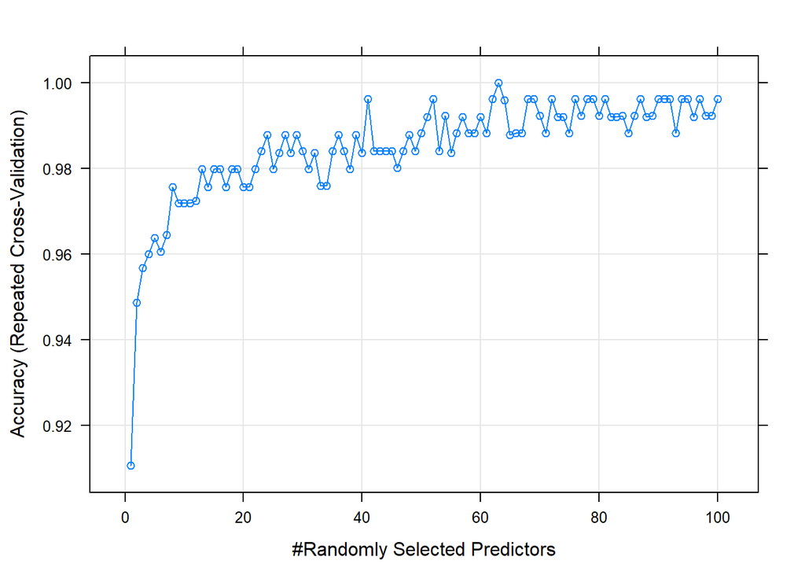

```r
plot(cv.rf.khan)
```

According to the result, the model with mtry being 63 reported perfect accuracy with cross-validation.

## Tree Boosting

First, I’ll use the defaults of the gbm function, a tree-boosting model with 100 trees, an interaction depth of 1, a shrinkage of 0.001, and a minimum number of 10 observations in the terminal node.

```r
library(gbm)
train = data.frame(cbind("Y"=ytrain, xtrain.mtx))
train$Y = as.factor(train$Y)

set.seed(471)
boost.khan = gbm(Y ~ ., data=train, distribution="multinomial",
                 n.trees=100, interaction.depth=1,
                 shrinkage=0.001, n.minobsinnode = 10)

pred.probs = predict(boost.khan, train[,-1], n.trees=100, type="response")

boost.khan.pred = rep(NA,0,63)
for(x in 1:63){
  boost.khan.pred[x] = which.max(pred.probs[x,,1])
}
sum(as.numeric(as.factor(ytrain) != boost.khan.pred))/63
```

```
## [1] 0
```

Well, the tree boosting model shows zero training error. Instead of blindly guessing and checking to see what other models might result in zero training errors, I’ll cross-validate this model along with other possible models.

I’ll try forests of 25, 50, 100, and 150 trees and a range of minimum numbers of observations in the terminal node: 2, 5, and 10.

```r
ctr = trainControl(method="cv", number=10) ## 10-fold CV

mygrid = expand.grid(n.trees=c(25,50,100,150), interaction.depth=1,
                     shrinkage=c(0.0001,0.001,0.01,0.1,0.2),
                     n.minobsinnode=c(2, 5, 10))

set.seed(471)
boost.caret = train(x=xtrain.mtx, y=ytrain.releveled, trControl=ctr,
                    method='gbm',
                    tuneGrid=mygrid,
                    preProc=c('center','scale'), verbose=F)

boost.caret
```

```
## Stochastic Gradient Boosting
##
##   63 samples
## 2308 predictors
##    4 classes: 'Type1', 'Type2', 'Type3', 'Type4'
##
## Pre-processing: centered (2308), scaled (2308)
## Resampling: Cross-Validated (10 fold)
## Summary of sample sizes: 57, 57, 55, 57, 57, 57, ...
## Resampling results across tuning parameters:
##
##   shrinkage  n.minobsinnode  n.trees  Accuracy   Kappa
##   1e-04       2               25      1.0000000  1.0000000
##   1e-04       2               50      1.0000000  1.0000000
##   1e-04       2              100      1.0000000  1.0000000
##   1e-04       2              150      1.0000000  1.0000000
##   1e-04       5               25      1.0000000  1.0000000
##   1e-04       5               50      1.0000000  1.0000000
##   1e-04       5              100      1.0000000  1.0000000
##   1e-04       5              150      1.0000000  1.0000000
##   1e-04      10               25      1.0000000  1.0000000
##   1e-04      10               50      1.0000000  1.0000000
##   1e-04      10              100      0.9833333  0.9714286
##   1e-04      10              150      0.9833333  0.9714286
##   1e-03       2               25      1.0000000  1.0000000
##   1e-03       2               50      1.0000000  1.0000000
##   1e-03       2              100      1.0000000  1.0000000
##   1e-03       2              150      1.0000000  1.0000000
##   1e-03       5               25      1.0000000  1.0000000
##   1e-03       5               50      1.0000000  1.0000000
##   1e-03       5              100      1.0000000  1.0000000
##   1e-03       5              150      1.0000000  1.0000000
##   1e-03      10               25      0.9666667  0.9474286
##   1e-03      10               50      1.0000000  1.0000000
##   1e-03      10              100      1.0000000  1.0000000
##   1e-03      10              150      1.0000000  1.0000000
##   1e-02       2               25      1.0000000  1.0000000
##   1e-02       2               50      1.0000000  1.0000000
##   1e-02       2              100      1.0000000  1.0000000
##   1e-02       2              150      1.0000000  1.0000000
```

[output cut: 22 more lines]

```
##   2e-01       2              100      1.0000000  1.0000000
##   2e-01       2              150      1.0000000  1.0000000
##   2e-01       5               25      1.0000000  1.0000000
##   2e-01       5               50      1.0000000  1.0000000
##   2e-01       5              100      1.0000000  1.0000000
##   2e-01       5              150      1.0000000  1.0000000
##   2e-01      10               25      1.0000000  1.0000000
##   2e-01      10               50      0.9833333  0.9769231
##   2e-01      10              100      1.0000000  1.0000000
##   2e-01      10              150      1.0000000  1.0000000
##
## Tuning parameter 'interaction.depth' was held constant at a value of 1
## Accuracy was used to select the optimal model using the largest value.
## The final values used for the model were n.trees = 25, interaction.depth
##  = 1, shrinkage = 1e-04 and n.minobsinnode = 2.
```

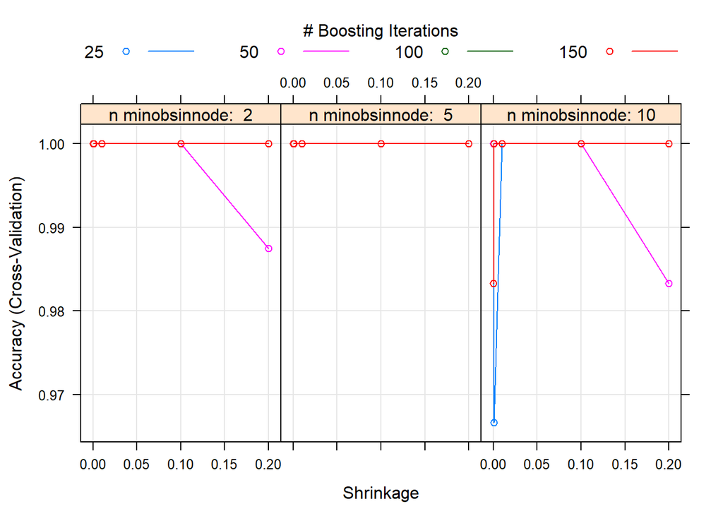

```r
plot(boost.caret)
```

```r
boost.caret$bestTune
```

```
##   n.trees interaction.depth shrinkage n.minobsinnode
## 1      25                 1     1e-04              2
```

Based on the results, the vast majority of tree boosting models had perfect validation accuracy, and the procedure chose the smallest possible hyperparameters.

I’ll run cross-validation again with even smaller hyperparameter choices.

```r
mygrid = expand.grid(n.trees=c(1,2,5,25,50), interaction.depth=1,
                     shrinkage=c(0.00001,0.0001,0.001,0.01),
                     n.minobsinnode=c(1,2))

set.seed(471)
boost.caret = train(x=xtrain.mtx, y=ytrain.releveled, trControl=ctr,
                    method='gbm',
                    tuneGrid=mygrid,
                    preProc=c('center','scale'), verbose=F)

boost.caret
```

```
## Stochastic Gradient Boosting
##
##   63 samples
## 2308 predictors
##    4 classes: 'Type1', 'Type2', 'Type3', 'Type4'
##
## Pre-processing: centered (2308), scaled (2308)
## Resampling: Cross-Validated (10 fold)
## Summary of sample sizes: 57, 57, 55, 57, 57, 57, ...
## Resampling results across tuning parameters:
##
##   shrinkage  n.minobsinnode  n.trees  Accuracy   Kappa
##   1e-05      1                1       0.7288095  0.6363637
##   1e-05      1                2       0.8232143  0.7593993
##   1e-05      1                5       0.9833333  0.9777778
##   1e-05      1               25       1.0000000  1.0000000
##   1e-05      1               50       1.0000000  1.0000000
##   1e-05      2                1       0.6797619  0.5762996
##   1e-05      2                2       0.8398810  0.7769414
##   1e-05      2                5       0.9833333  0.9769231
##   1e-05      2               25       1.0000000  1.0000000
##   1e-05      2               50       1.0000000  1.0000000
##   1e-04      1                1       0.6915476  0.5988390
##   1e-04      1                2       0.9157143  0.8800165
##   1e-04      1                5       1.0000000  1.0000000
##   1e-04      1               25       1.0000000  1.0000000
##   1e-04      1               50       1.0000000  1.0000000
##   1e-04      2                1       0.6504762  0.5355048
##   1e-04      2                2       0.8055952  0.7288221
##   1e-04      2                5       0.9375000  0.9127778
##   1e-04      2               25       1.0000000  1.0000000
##   1e-04      2               50       1.0000000  1.0000000
##   1e-03      1                1       0.6644048  0.5463350
##   1e-03      1                2       0.8696429  0.8176147
##   1e-03      1                5       0.9416667  0.9183372
##   1e-03      1               25       1.0000000  1.0000000
##   1e-03      1               50       1.0000000  1.0000000
##   1e-03      2                1       0.6879762  0.5888138
##   1e-03      2                2       0.8555952  0.7970937
##   1e-03      2                5       0.9833333  0.9777778
##   1e-03      2               25       1.0000000  1.0000000
##   1e-03      2               50       1.0000000  1.0000000
##   1e-02      1                1       0.8522619  0.8025455
##   1e-02      1                2       0.9014286  0.8660837
##   1e-02      1                5       0.9541667  0.9360000
##   1e-02      1               25       1.0000000  1.0000000
##   1e-02      1               50       1.0000000  1.0000000
##   1e-02      2                1       0.6826190  0.5772477
##   1e-02      2                2       0.8841667  0.8394219
##   1e-02      2                5       0.9833333  0.9777778
##   1e-02      2               25       1.0000000  1.0000000
##   1e-02      2               50       1.0000000  1.0000000
##
## Tuning parameter 'interaction.depth' was held constant at a value of 1
## Accuracy was used to select the optimal model using the largest value.
## The final values used for the model were n.trees = 5, interaction.depth
##  = 1, shrinkage = 1e-04 and n.minobsinnode = 1.
```

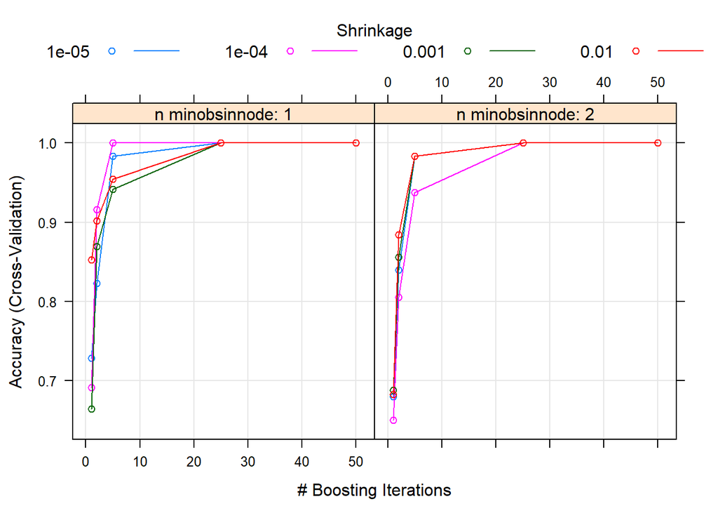

```r
plot(boost.caret)
```

```r
boost.caret$bestTune
```

```
##    n.trees interaction.depth shrinkage n.minobsinnode
## 13       5                 1     1e-04              1
```

I’ll do one more round of cross-validation to really fine-tune these hyperparameters to get the simplest model that has perfect cross-validation accuracy.

```r
mygrid = expand.grid(n.trees=c(1,2,3,4,5), interaction.depth=1,
                     shrinkage=c(0.00005,0.000075,0.0001,0.0005),
                     n.minobsinnode=1)

set.seed(471)
boost.caret = train(x=xtrain.mtx, y=ytrain.releveled, trControl=ctr,
                    method='gbm',
                    tuneGrid=mygrid,
                    preProc=c('center','scale'), verbose=F)

boost.caret
```

```
## Stochastic Gradient Boosting
##
##   63 samples
## 2308 predictors
##    4 classes: 'Type1', 'Type2', 'Type3', 'Type4'
##
## Pre-processing: centered (2308), scaled (2308)
## Resampling: Cross-Validated (10 fold)
## Summary of sample sizes: 57, 57, 55, 57, 57, 57, ...
## Resampling results across tuning parameters:
##
##   shrinkage  n.trees  Accuracy   Kappa
##   5.0e-05    1        0.7180952  0.6234866
##   5.0e-05    2        0.9240476  0.8923007
##   5.0e-05    3        0.9675000  0.9517287
##   5.0e-05    4        0.9875000  0.9829787
##   5.0e-05    5        0.9875000  0.9829787
##   7.5e-05    1        0.7230952  0.6193857
##   7.5e-05    2        0.8355952  0.7712137
##   7.5e-05    3        0.9107143  0.8752603
##   7.5e-05    4        0.9232143  0.8919231
##   7.5e-05    5        0.9232143  0.8910684
##   1.0e-04    1        0.8240476  0.7579575
##   1.0e-04    2        0.9175000  0.8863398
##   1.0e-04    3        0.9800000  0.9705882
##   1.0e-04    4        1.0000000  1.0000000
##   1.0e-04    5        0.9875000  0.9822222
##   5.0e-04    1        0.8058333  0.7344350
##   5.0e-04    2        0.9300000  0.8985278
##   5.0e-04    3        0.9633333  0.9456731
##   5.0e-04    4        0.9800000  0.9687500
##   5.0e-04    5        0.9800000  0.9687500
##
## Tuning parameter 'interaction.depth' was held constant at a value of
##  1
## Tuning parameter 'n.minobsinnode' was held constant at a value of 1
## Accuracy was used to select the optimal model using the largest value.
## The final values used for the model were n.trees = 4, interaction.depth
##  = 1, shrinkage = 1e-04 and n.minobsinnode = 1.
```

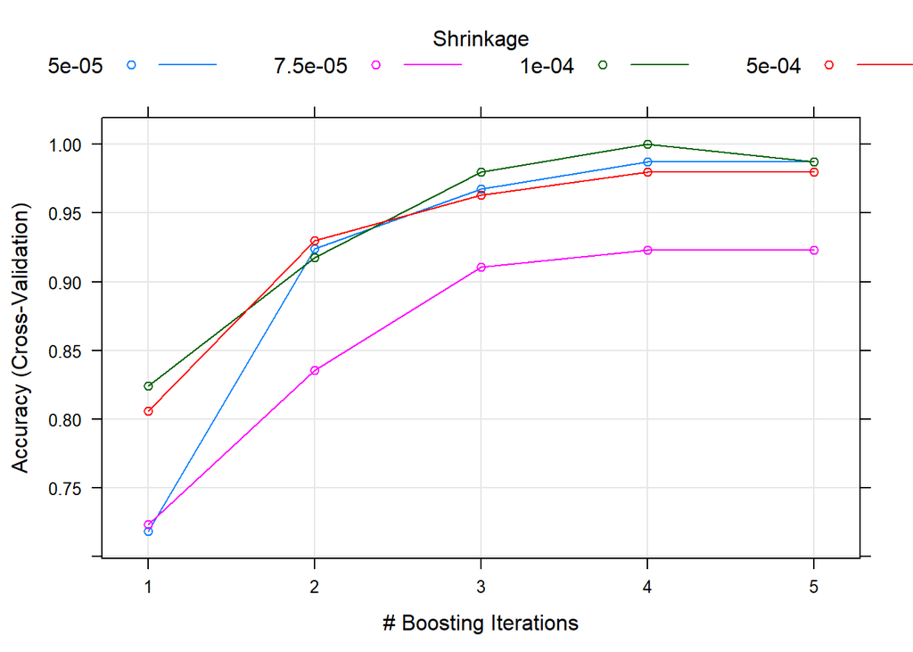

```r
plot(boost.caret)
```

```r
boost.caret$bestTune
```

```
##    n.trees interaction.depth shrinkage n.minobsinnode
## 14       4                 1     1e-04              1
```

I will select the hyperparameters above as our best tree boosting model.

## Test error of each model

### RandomForest

```r
rf.test.pred = predict(cv.rf.khan$finalModel, xtest)

sum(as.numeric(as.numeric(rf.test.pred) != ytest))
```

```
## [1] 2
```

```r
cbind(ytest, rf.test.pred)
```

```
##     ytest rf.test.pred
## V1      3            3
## V2      2            2
## V4      4            4
## V6      2            2
## V7      1            1
## V8      3            3
## V10     4            4
## V12     2            2
## V14     3            3
## V15     1            1
## V16     3            3
## V17     4            4
## V18     1            1
## V19     2            2
## V20     2            2
## V21     2            2
## V22     4            4
## V23     3            4
## V24     4            4
## V25     3            4
```

There are 2 test errors, for a test error rate of 2/20 = 10%.

### Forest Boosting

Now we’ll compute the test errors of the random forest boosting model.

```r
boost.test.probs = predict(boost.caret$finalModel, xtest, type="response",
                           n.trees=boost.caret$finalModel$n.trees)
boost.test.pred  = rep(NA,0,20)
for(x in 1:20){
  boost.test.pred[x] = which.max(boost.test.probs[x,,1])
}

sum(as.numeric(ytest != boost.test.pred))
```

```
## [1] 3
```

```r
cbind(ytest, boost.test.pred)
```

```
##       ytest boost.test.pred
##  [1,]     3               1
##  [2,]     2               1
##  [3,]     4               4
##  [4,]     2               2
##  [5,]     1               1
##  [6,]     3               3
##  [7,]     4               4
##  [8,]     2               2
##  [9,]     3               3
## [10,]     1               1
## [11,]     3               3
## [12,]     4               4
## [13,]     1               1
## [14,]     2               2
## [15,]     2               1
## [16,]     2               2
## [17,]     4               4
## [18,]     3               3
## [19,]     4               4
## [20,]     3               3
```

There are 3 testing errors, the test error rate of boosting model is 3/20 = 15%.

Therefore, our best model is our random forest with the hyperparameter `mtry` equal to 63.